# Assignment 1 Wakerley

Author

Kyle Wakerley

## Question 1: EDA

```r
# loading in data
mi_2005 = read.csv("C:/Users/kylew/Downloads/MI_2005_PM25.csv")
mi_2025 = read.csv("C:/Users/kylew/Downloads/MI_2025_PM25.csv")
library(dplyr)
```

```r
# Checking Dimensions for 2005
dim(mi_2005)
```

```
[1] 5280   22
```

```r
# Checking Dimensions for 2025
dim(mi_2025)
```

```
[1] 9934   22
```

```r
str(mi_2005) #same variables for 2025
```

```
'data.frame':   5280 obs. of  22 variables:
 $ Date                          : chr  "01/01/2005" "01/02/2005" "01/03/2005" "01/04/2005" ...
 $ Source                        : chr  "AQS" "AQS" "AQS" "AQS" ...
 $ Site.ID                       : int  260050003 260050003 260050003 260050003 260050003 260050003 260050003 260050003 260050003 260050003 ...
 $ POC                           : int  1 1 1 1 1 1 1 1 1 1 ...
 $ Daily.Mean.PM2.5.Concentration: num  9.3 7 15.7 13.4 5.3 4 12.6 29 15.5 13.2 ...
 $ Units                         : chr  "ug/m3 LC" "ug/m3 LC" "ug/m3 LC" "ug/m3 LC" ...
 $ Daily.AQI.Value               : int  51 39 63 59 29 22 58 88 63 59 ...
 $ Local.Site.Name               : chr  "966 32nd St (Holland)" "966 32nd St (Holland)" "966 32nd St (Holland)" "966 32nd St (Holland)" ...
 $ Daily.Obs.Count               : int  1 1 1 1 1 1 1 1 1 1 ...
 $ Percent.Complete              : num  100 100 100 100 100 100 100 100 100 100 ...
 $ AQS.Parameter.Code            : int  88101 88101 88101 88101 88101 88101 88101 88101 88101 88101 ...
 $ AQS.Parameter.Description     : chr  "PM2.5 - Local Conditions" "PM2.5 - Local Conditions" "PM2.5 - Local Conditions" "PM2.5 - Local Conditions" ...
 $ Method.Code                   : int  118 118 118 118 118 118 118 118 118 118 ...
 $ Method.Description            : chr  "R & P Model 2025 PM2.5 Sequential w/WINS" "R & P Model 2025 PM2.5 Sequential w/WINS" "R & P Model 2025 PM2.5 Sequential w/WINS" "R & P Model 2025 PM2.5 Sequential w/WINS" ...
 $ CBSA.Code                     : int  26090 26090 26090 26090 26090 26090 26090 26090 26090 26090 ...
 $ CBSA.Name                     : chr  "Holland, MI" "Holland, MI" "Holland, MI" "Holland, MI" ...
 $ State.FIPS.Code               : int  26 26 26 26 26 26 26 26 26 26 ...
 $ State                         : chr  "Michigan" "Michigan" "Michigan" "Michigan" ...
 $ County.FIPS.Code              : int  5 5 5 5 5 5 5 5 5 5 ...
 $ County                        : chr  "Allegan" "Allegan" "Allegan" "Allegan" ...
 $ Site.Latitude                 : num  42.8 42.8 42.8 42.8 42.8 ...
 $ Site.Longitude                : num  -86.1 -86.1 -86.1 -86.1 -86.1 ...
```

```r
summary(mi_2005$Daily.Mean.PM2.5.Concentration)
```

```
   Min. 1st Qu.  Median    Mean 3rd Qu.    Max.
   0.00    6.20   11.00   13.77   18.70   81.60
```

```r
summary(mi_2025$Daily.Mean.PM2.5.Concentration)
```

```
   Min. 1st Qu.  Median    Mean 3rd Qu.    Max.
  0.000   4.000   6.300   8.305  10.100 116.000
```

```r
summary(mi_2025$Percent.Complete)
```

```
   Min. 1st Qu.  Median    Mean 3rd Qu.    Max.
    100     100     100     100     100     100
```

```r
summary(mi_2005$Percent.Complete)
```

```
   Min. 1st Qu.  Median    Mean 3rd Qu.    Max.
    100     100     100     100     100     100
```

```r
length(unique(mi_2025$Site.ID))
```

```
[1] 27
```

```r
length(unique(mi_2005$Site.ID))
```

```
[1] 34
```

```r
head(mi_2005) %>% select(Date, Daily.Mean.PM2.5.Concentration, Local.Site.Name, County)
```

```
        Date Daily.Mean.PM2.5.Concentration       Local.Site.Name  County
1 01/01/2005                            9.3 966 32nd St (Holland) Allegan
2 01/02/2005                            7.0 966 32nd St (Holland) Allegan
3 01/03/2005                           15.7 966 32nd St (Holland) Allegan
4 01/04/2005                           13.4 966 32nd St (Holland) Allegan
5 01/05/2005                            5.3 966 32nd St (Holland) Allegan
6 01/06/2005                            4.0 966 32nd St (Holland) Allegan
```

```r
#Selecting only certain rows to reduce viewing clutter.

tail(mi_2005) %>% select(Date, Daily.Mean.PM2.5.Concentration, Local.Site.Name, County)
```

```
           Date Daily.Mean.PM2.5.Concentration Local.Site.Name County
5275 09/01/2005                           12.8                  Wayne
5276 09/07/2005                           30.4                  Wayne
5277 09/13/2005                           46.5                  Wayne
5278 09/25/2005                           24.4                  Wayne
5279 10/01/2005                           24.0                  Wayne
5280 10/07/2005                            2.9                  Wayne
```

```r
head(mi_2025) %>% select(Date, Daily.Mean.PM2.5.Concentration, Local.Site.Name, County)
```

```
        Date Daily.Mean.PM2.5.Concentration       Local.Site.Name  County
1 01/01/2025                            3.7 966 32nd St (Holland) Allegan
2 01/02/2025                            4.5 966 32nd St (Holland) Allegan
3 01/03/2025                            3.8 966 32nd St (Holland) Allegan
4 01/04/2025                            3.3 966 32nd St (Holland) Allegan
5 01/05/2025                            4.6 966 32nd St (Holland) Allegan
6 01/06/2025                            3.3 966 32nd St (Holland) Allegan
```

```r
tail(mi_2025) %>% select(Date, Daily.Mean.PM2.5.Concentration, Local.Site.Name, County)
```

```
           Date Daily.Mean.PM2.5.Concentration      Local.Site.Name County
9929 12/26/2025                            5.2 Military Park (GHIB)  Wayne
9930 12/27/2025                            5.4 Military Park (GHIB)  Wayne
9931 12/28/2025                           10.7 Military Park (GHIB)  Wayne
9932 12/29/2025                            2.4 Military Park (GHIB)  Wayne
9933 12/30/2025                            3.4 Military Park (GHIB)  Wayne
9934 12/31/2025                            6.7 Military Park (GHIB)  Wayne
```

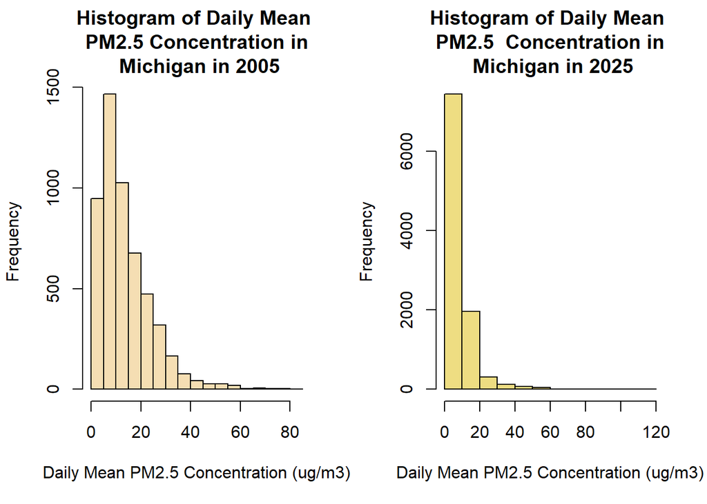

```r
par(mfrow = c(1,2))
hist(mi_2005$Daily.Mean.PM2.5.Concentration, xlab = "Daily Mean PM2.5 Concentration (ug/m3)", ylab = "Frequency", main = "Histogram of Daily Mean \n PM2.5 Concentration in \n Michigan in 2005", col = "wheat")

hist(mi_2025$Daily.Mean.PM2.5.Concentration, xlab = "Daily Mean PM2.5 Concentration (ug/m3)", ylab = "Frequency", main = "Histogram of Daily Mean \n PM2.5  Concentration in \n Michigan in 2025", col = "lightgoldenrod")
```

### Summary of EDA findings

After loading in the data, a few things stand out. The dimensions of the two datasets are different; the 2005 dataset has 5280 rows and 22 columns compared to 9934 rows and 22 columns for the 2025 dataset. The 2005 Data comes from a total of 34 sites compared to just 27 in 2025. I also looked into the variables and what they describe. POC (int) describes the method of data collection and ranges from 1 to 5, with most observations being 1. The Daily.Mean.PM2.5.Concentration variable (num) describes exactly that: mean PM2.5 concentrations at a specific testing site on a particular day. Daily.AQI.Value (int) describes the Air Quality Index value in the location that day. Finally there is information data on where the site is located (County.FIPS.Code, Site.Latitude, Site.Longitude, Local.Site.Name, Site.ID). Percent.Complete is also an intriguing value but strictly irrelevant for this investigation as a quick dive reveals that it is 100 percent in each case. A summary of the main variable Daily.Mean.PM2.5.Concentration for the two years shows a few differences. Both years are skewed to the right, with the 2025 year being more concentrated towards zero compared to 2005. Michigan in 2005 had a Minimum pm2.5 value of 0, a Median of 11, a Mean of 13.77, and a max of 81.6. Comparatively, 2025 Michigan had a Minimum PM2.5 value of 0 (the same), a Median of 6.3 (lower), a Mean of 8.305 (lower), and a max of 116 (higher). This might suggest that on average the sites recorded lower PM2.5 values in 2025 compared to 2005, however some sites have much higher PM2.5 values.

## Question 2

```r
micombined = rbind(mi_2005, mi_2025)

micombined$date_converted = as.Date(micombined$Date, format = "%m/%d/%Y")
micombined$Year = format(micombined$date_converted, "%Y")

micombined_f = micombined %>% rename(
  mean2.5 = Daily.Mean.PM2.5.Concentration,
  AQI = Daily.AQI.Value,
  site = Local.Site.Name,
  lat = Site.Latitude,
  id = Site.ID,
  lon = Site.Longitude)

head(micombined_f) %>% select(Date, id, mean2.5, site, lat, lon)
```

```
        Date        id mean2.5                  site      lat       lon
1 01/01/2005 260050003     9.3 966 32nd St (Holland) 42.76779 -86.14858
2 01/02/2005 260050003     7.0 966 32nd St (Holland) 42.76779 -86.14858
3 01/03/2005 260050003    15.7 966 32nd St (Holland) 42.76779 -86.14858
4 01/04/2005 260050003    13.4 966 32nd St (Holland) 42.76779 -86.14858
5 01/05/2005 260050003     5.3 966 32nd St (Holland) 42.76779 -86.14858
6 01/06/2005 260050003     4.0 966 32nd St (Holland) 42.76779 -86.14858
```

```r
#Selected only certain columns for readability.
```

## Question 3

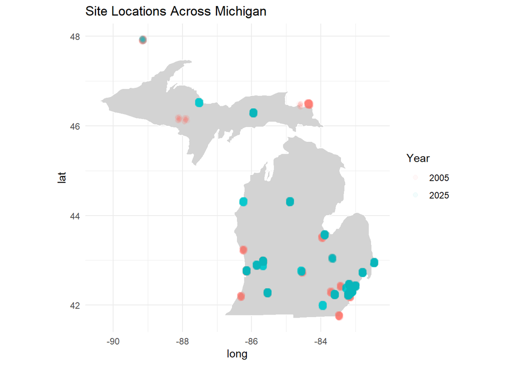

```r
library(ggplot2)
#install.packages("maps")
library(maps)
us_map = map_data("state")
mi_map = us_map %>% filter(region == "michigan")

ggplot() + geom_polygon(data = mi_map, aes(x = long, y = lat, group = group), fill = "lightgrey", color = "white") + geom_point(
    data = micombined_f,
    aes(x = lon, y = lat, color = factor(Year)),
    size = 2, alpha = 0.05, position = position_jitter(width = 0.05, height = 0.05)) + coord_fixed(1.3) + labs(color = "Year") + theme_minimal() +
  ggtitle("Site Locations Across Michigan")
```

```r
sites_2005 = unique(mi_2005$Site.ID)
sites_2025 = unique(mi_2025$Site.ID)

setdiff(sites_2025, sites_2005) #10 sites in 2025 not in 2005
```

```
 [1] 260650018 260810023 260910007 261010922 261030013 261630093 261630097
 [8] 261630098 261630099 261630100
```

```r
setdiff(sites_2005, sites_2025) #17 in 2005 but not 2025
```

```
 [1] 260210014 260330901 260330902 260330903 260430002 260650012 260710001
 [8] 261150005 261210040 261450018 261610005 261630016 261630025 261630036
[15] 261630038 261630039 261639901
```

```r
intersect(sites_2025, sites_2005) #17 in both
```

```
 [1] 260050003 260170014 260490021 260770008 260810020 260839000 260990009
 [8] 261130001 261250001 261390005 261470005 261530001 261610008 261630001
[15] 261630015 261630019 261630033
```

```r
(unique(mi_2025$Local.Site.Name))
```

```
 [1] "966 32nd St (Holland)"
 [2] "BAY CITY -JENISON ST ABOUT 70 FT WEST, 2 LANE RESIDENTIAL"
 [3] "WHALEY PK 3610 IOWA (FLINT)"
 [4] "Lansing - Filley"
 [5] "Kalamazoo Fairgrounds"
 [6] "GR-MONROE"
 [7] "GRAND RAPIDS NEAR ROADWAY"
 [8] "Isle Royale NP"
 [9] "6792 RAISIN CENTER HWY, LENAWEE CO.RD.COMM.OWNER, TECUMSEH"
[10] "New Haven"
[11] ""
[12] "Negaunee Township, Off Pump House Road, Pump House #2"
[13] "LOCATED ABOUT 1/4 MILE WEST OF SITE"
[14] "Oak Park"
[15] "Jenison"
[16] "Port Huron"
[17] "Seney National Wildlife Refuge, Germfask, MI"
[18] "YPSILANTI TOWNER ST, SOUTH;"
[19] "Allen Park"
[20] "DETROIT-SOUTHWEST (DET-SW)"
[21] "East 7 Mile"
[22] "PROPERTY OWNED BY DEARBORN PUBLIC SCHOOLS"
[23] "Eliza Howell-NR"
[24] "NMH48217 NEW MT HERMAN CHURCH"
[25] "DP4th - Detroit Police 4th Precinct (near GHIB)"
[26] "TRINITY ST MARKS - Gordy Howe International Bridge (GHIB)"
[27] "Military Park (GHIB)"
```

```r
(unique(mi_2005$Local.Site.Name))
```

```
 [1] "966 32nd St (Holland)"
 [2] "BAY CITY -JENISON ST ABOUT 70 FT WEST, 2 LANE RESIDENTIAL"
 [3] "Coloma site 4689 Defield Rd, Coloma, MI PAW PAW WWTP"
 [4] "NORTH OF EASTERDAY AVE LK SUPERIOR STATE UNIV"
 [5] "SOUTH OF SCHOOL"
 [6] "NORTH OF EASTERDAY AVENUE"
 [7] "WHALEY PK 3610 IOWA (FLINT)"
 [8] ""
 [9] "Kalamazoo Fairgrounds"
[10] "GR-MONROE"
[11] "Isle Royale NP"
[12] "New Haven"
[13] "LOCATED ABOUT 1/4 MILE WEST OF SITE"
[14] "DEAN ROAD DEAD-ENDS AT SITE, 200 FT WEST"
[15] "APPLE AVE, NORTH 375 FT; AMBROSIA ST, EAST 184 FT"
[16] "Oak Park"
[17] "Jenison"
[18] "PIERCE RD, SOUTH 250 FT., 2 LANE PAVED"
[19] "Port Huron"
[20] "Seney National Wildlife Refuge, Germfask, MI"
[21] "YPSILANTI TOWNER ST, SOUTH;"
[22] "Allen Park"
[23] "DETROIT-SOUTHWEST (DET-SW)"
[24] "DET-LINWOOD"
[25] "East 7 Mile"
[26] "SCHOOLCRAFT COLLEGE"
[27] "PROPERTY OWNED BY DEARBORN PUBLIC SCHOOLS"
[28] "92 FEET FROM WHE STREET"
[29] "Newberry School"
[30] "FIA/Lafayette"
```

```r
(unique(mi_2005$Site.ID))
```

```
 [1] 260050003 260170014 260210014 260330901 260330902 260330903 260430002
 [8] 260490021 260650012 260710001 260770008 260810020 260839000 260990009
[15] 261130001 261150005 261210040 261250001 261390005 261450018 261470005
[22] 261530001 261610005 261610008 261630001 261630015 261630016 261630019
[29] 261630025 261630033 261630036 261630038 261630039 261639901
```

```r
micombined_f %>% filter(site == "SOUTH OF SCHOOL") %>% distinct(id)
```

```
         id
1 260330902
2 260330903
```

```r
# 4 blank sites with no name
# NORTH OF EASTERDAY AVENUE moved slightly (2 sites)
#SOUTH OF SCHOOL moved slightly (2 sites)
```

## Spatial Distribution of Sites in Michigan From 2005 to 2025

Looking at how sites are distributed across Michigan in 2005 and 2025, there appears to be a spatial difference. 10 new sites have popped up in 2025 compared to 2005. 3 of these appear to be in the UP, some are scattered in West Michigan, a few in central Michigan, and the rest are concentrated near Detroit. 17 sites that were present in 2005 are no longer collecting data. 5 of these were in the UP, and one was near the Ohio border. Sites located near Detroit have moved slightly (perhaps to more favorable locations). There are 17 sites that are shared between both years. The sites named NORTH OF EASTERDAY AVENUE, and SOUTH OF SCHOOL moved slightly and thus have 2 site IDs and locations (Both from 2005). There are 4 sites with no site name, but a unique site ID.

## Question 4: Checking for implausible values of PM2.5

```r
summary(micombined_f$mean2.5)
```

```
   Min. 1st Qu.  Median    Mean 3rd Qu.    Max.
    0.0     4.5     7.4    10.2    12.5   116.0
```

```r
micombined_f %>% filter(mean2.5 > 100) %>% as_tibble()
```

```
# A tibble: 2 × 24
  Date       Source        id   POC mean2.5 Units      AQI site  Daily.Obs.Count
  <chr>      <chr>      <int> <int>   <dbl> <chr>    <int> <chr>           <int>
1 06/03/2025 AQS    261030013     1    101. ug/m3 LC   183 Nega…               1
2 07/30/2025 AQS    261030013     1    116  ug/m3 LC   193 Nega…               1
# ℹ 15 more variables: Percent.Complete <dbl>, AQS.Parameter.Code <int>,
#   AQS.Parameter.Description <chr>, Method.Code <int>,
#   Method.Description <chr>, CBSA.Code <int>, CBSA.Name <chr>,
#   State.FIPS.Code <int>, State <chr>, County.FIPS.Code <int>, County <chr>,
#   lat <dbl>, lon <dbl>, date_converted <date>, Year <chr>
```

```r
micombined_f %>% filter(site == "Negaunee Township, Off Pump House Road, Pump House #2", mean2.5 > 40 ) %>% select(Date, mean2.5, AQI)
```

```
        Date mean2.5 AQI
1 06/03/2025   100.6 183
2 07/12/2025    42.1 117
3 07/13/2025    72.6 163
4 07/29/2025    45.5 126
5 07/30/2025   116.0 193
6 07/31/2025    79.3 168
7 08/01/2025    59.2 154
8 08/02/2025    62.6 156
9 08/06/2025    40.8 114
```

```r
#Both days correspond to Canadian wild fire smoke. Likely real values.

mean(is.na(micombined_f$mean2.5)) # Zero NA values
```

```
[1] 0
```

There are two values, both in 2025, that exceed 100 ug/m3 LC. Both of these occurred at the same site, “Negaunee Township, Off Pump House Road, Pump House #2” on June 3rd 2025 and July 30th 2025. Looking on Google for these dates shows that Canadian Wildfire smoke had greatly worsened the air quality (and thus PM2.5) in the Michigan Area. This site in particular was hit especially hard due to its location in the upper peninsula. Looking at the daily average PM2.5 values I found no missing values. Overall, there are no data points that require further examination or need to be removed.

## Method Code Analysis

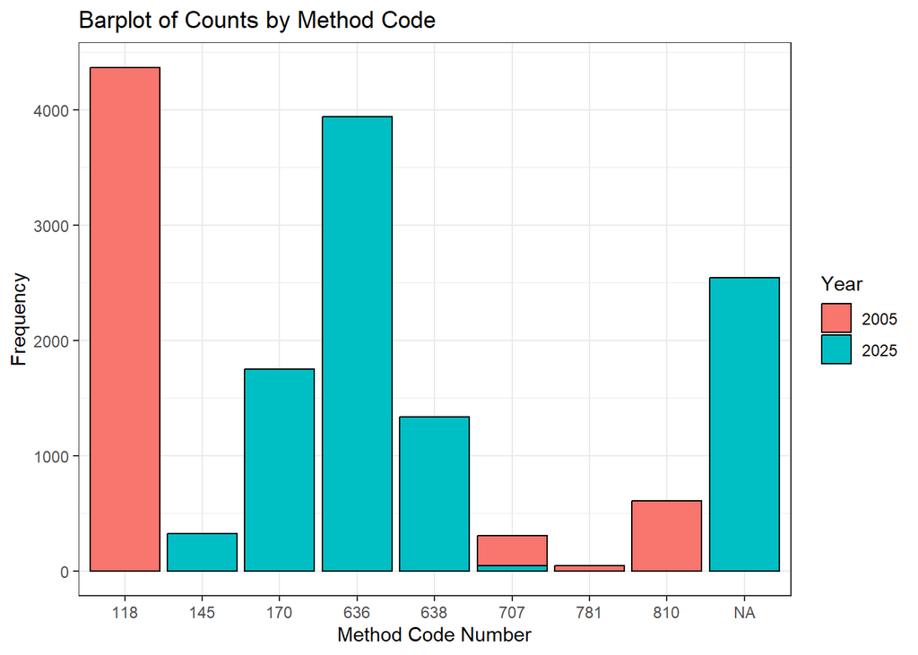

```r
ggplot(data = micombined_f) + geom_bar(aes(x = as.character(Method.Code), fill = Year), color = "black")+ theme_bw() + labs(x = "Method Code Number", y = "Frequency", title = "Barplot of Counts by Method Code")
```

```r
micombined_f %>% group_by(Year) %>% summarize(Prop_Missing = mean(is.na(Method.Code)))
```

```
# A tibble: 2 × 2
  Year  Prop_Missing
  <chr>        <dbl>
1 2005         0
2 2025         0.256
```

The two most common methods used in our data are method code numbers 118 and 636. Looking at the EPA code table 118 corresponds to “R & P MODEL 2025 PM2.5 SEQUNTL” which is a Gravimetric recording strategy. Code 636 is referred to as “Teledyne T640 at 5.0 LPM w/Network Data Alignment enabled”. This is a continuous Broadband Spectroscopy technique. Temporally, I found that 2005 sites did not ever leave the method code blank, as 0% of the Method.Code column is missing. However, in 2025, more than a quarter of all entries are missing the method code (25.6%). This is important because we cannot fully compare the distribution of method codes across the years with this amount of missing data. The missing data could belong to any of the method codes shown in the barplot, or perhaps a brand new one.

## Question 5

### Whole State Analysis

```r
library(tidyr)
# Spatial Analysis for Primary Research Question

#Level One: Whole State
mean(mi_2005$Daily.Mean.PM2.5.Concentration) - mean(mi_2025$Daily.Mean.PM2.5.Concentration)
```

```
[1] 5.467006
```

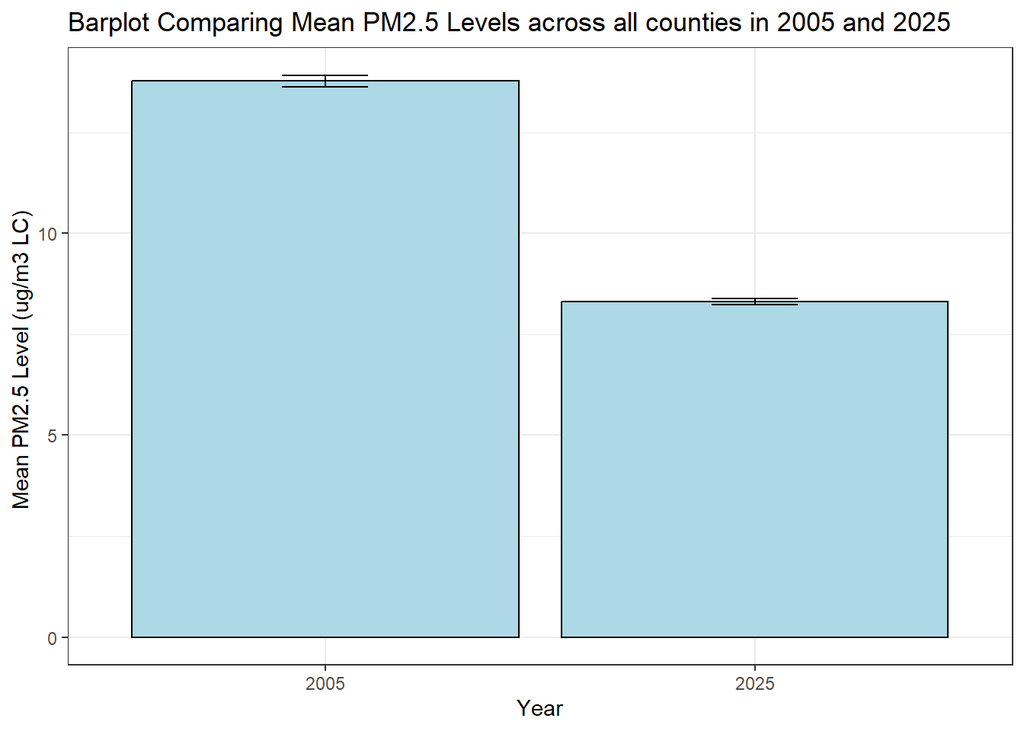

```r
micombined_f %>%
  group_by(Year) %>%
  summarize(mean = mean(mean2.5, na.rm = TRUE), n = n(), sd = sd(mean2.5, na.rm = TRUE), se = sd / sqrt(n)) %>%
 ggplot(aes(x = Year, y = mean)) +
  geom_bar(stat = "identity", fill = "lightblue", color = "black") +
  labs(y = "Mean PM2.5 Level (ug/m3 LC) ", title = "Barplot Comparing Mean PM2.5 Levels across all counties in 2005 and 2025") +
  theme_bw() +
  geom_errorbar(aes(ymin = mean - se, ymax = mean + se), width = 0.2)
```

From a very simple whole-state level, we can see that average daily mean PM2.5 concentrations decreased 5.467 ug/m3 LC from 2005 to 2025. So from the perspective of the entire state, levels of PM2.5 have improved in the last 20 years.

### County Analysis

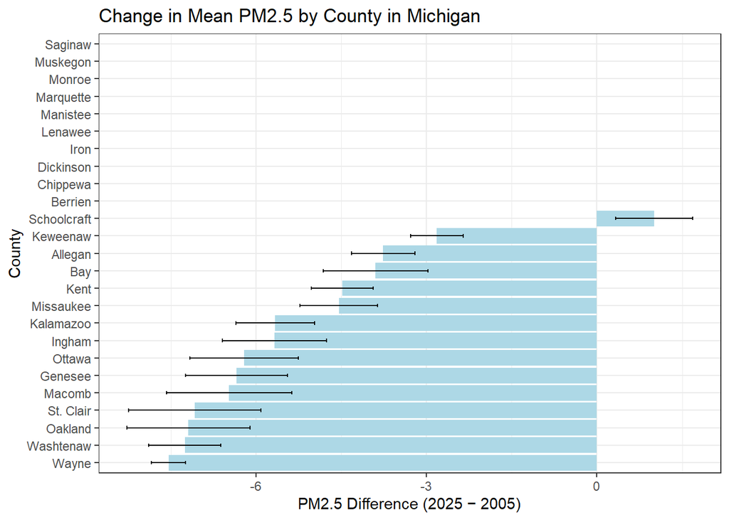

```r
#Level Two: By County
# Creating difference in 2025 vs 2005 across all counties in Michigan
micombined_f %>% group_by(County, Year) %>%
  summarize(mean2.5_county = mean(mean2.5, na.rm = TRUE), sd = sd(mean2.5, na.rm = TRUE), n = n(), se = sd / sqrt(n)) %>%
  pivot_wider(names_from = Year, values_from = c(mean2.5_county, se, sd, n))  %>%
   mutate(Mean_Diff = mean2.5_county_2025 - mean2.5_county_2005, SE_Diff = sqrt(se_2005^2 + se_2025^2)) %>%
   ggplot(aes(x = reorder(County, Mean_Diff), y = Mean_Diff)) +
    geom_col(fill = "lightblue") +
    geom_errorbar(aes(ymin = Mean_Diff - SE_Diff, ymax = Mean_Diff + SE_Diff), width = 0.2) +
    coord_flip() +
    theme_bw() +
    labs(x = "County", y = "PM2.5 Difference (2025 − 2005)", title = "Change in Mean PM2.5 by County in Michigan")
```

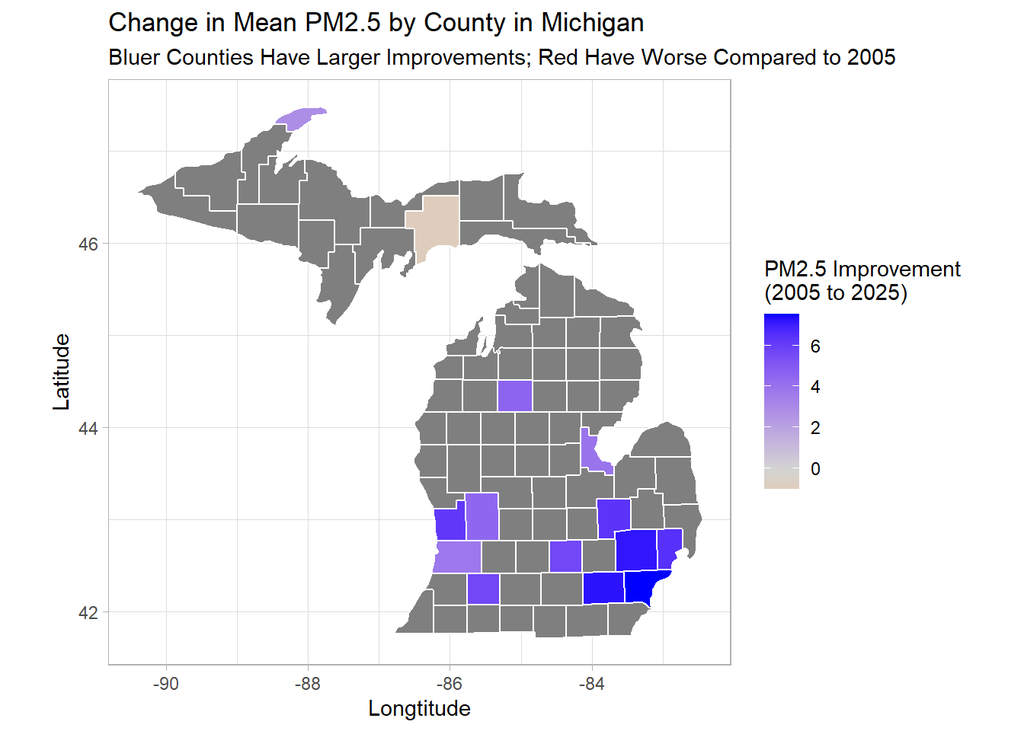

```r
#Combining data with latitude and longitude data for each county

Air_improvement = micombined_f %>% group_by(County, Year) %>% summarize(mean2.5 = mean(mean2.5)) %>% pivot_wider(names_from = Year, values_from = mean2.5) %>% mutate(Mean_Diff = `2025`- `2005`, Improvement = -Mean_Diff)
mi_counties = map_data("county", "michigan") %>%
  mutate(County = tools::toTitleCase(subregion)) #Used AI assistance to help correct case issues

mi_map_diff = mi_counties %>%
  left_join(Air_improvement, by = "County")

#Plotting improvements on the Michigan map

ggplot(mi_map_diff) +
  geom_polygon(
    aes(x = long, y = lat, group = group, fill = Improvement), color = "white", linewidth = 0.5) +
  scale_fill_gradient2(low = "orange", mid = "lightgray", high = "blue",midpoint = 0,name = "PM2.5 Improvement\n(2005 to 2025)") +
  coord_fixed(1.3) +
  labs(title = "Change in Mean PM2.5 by County in Michigan",
    subtitle = "Bluer Counties Have Larger Improvements; Red Have Worse Compared to 2005", x = "Longtitude", y = "Latitude") + theme_light()
```

```r
Air_improvement %>% filter(!is.na(Improvement))
```

```
# A tibble: 15 × 5
# Groups:   County [15]
   County      `2005` `2025` Mean_Diff Improvement
   <chr>        <dbl>  <dbl>     <dbl>       <dbl>
 1 Allegan      12.7    8.95     -3.76        3.76
 2 Bay          12.4    8.54     -3.89        3.89
 3 Genesee      12.9    6.54     -6.34        6.34
 4 Ingham       13.5    7.87     -5.67        5.67
 5 Kalamazoo    14.7    9.07     -5.66        5.66
 6 Kent         14.3    9.81     -4.48        4.48
 7 Keweenaw      4.66   1.84     -2.82        2.82
 8 Macomb       14.4    7.88     -6.47        6.47
 9 Missaukee     9.86   5.32     -4.54        4.54
10 Oakland      15.4    8.21     -7.19        7.19
11 Ottawa       13.9    7.74     -6.21        6.21
12 Schoolcraft   5.56   6.57      1.00       -1.00
13 St. Clair    15.0    7.97     -7.08        7.08
14 Washtenaw    15.2    7.91     -7.25        7.25
15 Wayne        16.5    9.01     -7.54        7.54
```

For the 25 counties in Michigan that measured PM2.5 levels, 10 of them did not have data for both 2005 and 2025. However for the 15 counties with data collected in both years, the average daily PM2.5 level was improved in 14 of them. Only Schoolcraft County, located in the upper peninsula, showed worsening PM2.5 levels in 2025 compared to 2005. This could be due to increased industry in the area that has popped up since 2005, or due to random chance. Visually on the Michigan map, we see moderate improvements in Western Michigan along with greater improvements in the Detroit suburb area.

### Wayne County Analysis

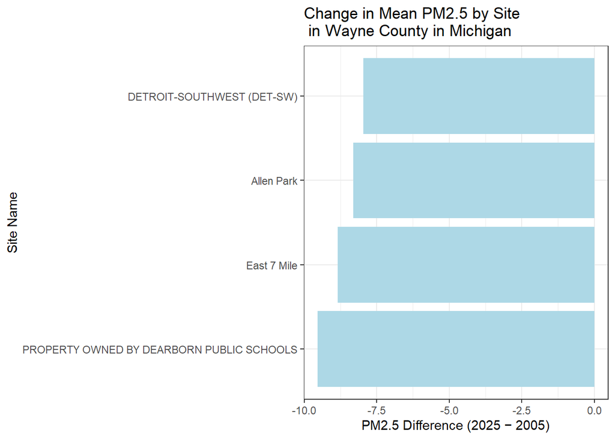

```r
# Level Three: Sites in Wayne County

Wayne_county = micombined_f %>% filter(County == "Wayne") %>% group_by(Year, site) %>% summarize(mean2.5 = mean(mean2.5)) %>% pivot_wider(names_from = Year, values_from = mean2.5) %>% mutate(Mean_Diff = `2025`- `2005`) %>% filter(!is.na(Mean_Diff))
ggplot(data = Wayne_county, aes(x = reorder(site, Mean_Diff), y = Mean_Diff)) + geom_col(fill = "lightblue") + coord_flip() + labs(x = "Site Name", y = "PM2.5 Difference (2025 − 2005)", title = "Change in Mean PM2.5 by Site \n in Wayne County in Michigan") + theme_bw()
```

```r
Wayne_county %>% rename(
  Site = site,
  `Mean Difference` = Mean_Diff
)
```

```
# A tibble: 4 × 4
  Site                                      `2005` `2025` `Mean Difference`
  <chr>                                      <dbl>  <dbl>             <dbl>
1 Allen Park                                  16.3   7.96             -8.31
2 DETROIT-SOUTHWEST (DET-SW)                  17.2   9.23             -7.96
3 East 7 Mile                                 16.4   7.57             -8.85
4 PROPERTY OWNED BY DEARBORN PUBLIC SCHOOLS   18.9   9.35             -9.54
```

There are 15 sites in Wayne county that collected data across the two years. Of these 15 sites, only 4 collected data in both 2005 and 2025. These sites are: Detroit-Southwest, Allen Park, East 7 Mile, and a property owned by Dearborn public schools. Although a small sample size, it is apparent that all 4 of these sites have had vast improvement in PM2.5 levels since 2005. All 4 of these sites have improvements over 7.5 ug/m3 LC, and the property owned by Dearborn public schools had close to a 10 ug/m3 LC improvement. From this we can hazard that the air quality has improved a lot in the Detroit area in the last 20 years.